# Using R for Econometrics and Statistics

Robin_Yao_Wenbin(StudentID:21912086)

2019.11.9

The function defined by myself that this document needs.

```r
ConcatDate <- function(Year , Month){
  ## transfer the year of int and month of int to character year+month
  if (Month < 10){
    paste(as.character(Year) , "-"  , "0" , as.character(Month) , sep = "")
  }
  else{
    paste(as.character(Year) , "-"  , as.character(Month) , sep = "")
  }
}

ConcatDate2 <- function(YearVec , MonthVec){
  DateVec<-vector(mode = "character",length=0)
  for (ind in 1:length(YearVec)){
    DateVec[ind] <- ConcatDate(YearVec[ind] , MonthVec[ind])
  }
  DateVec
}

L2Norm <- function(x){
  result <- sqrt(sum(x ^ 2 , na.rm = TRUE))
  result
}

L1Norm <- function(x){
  result <- sum(abs(x) , na.rm = TRUE)
  result
}
```

# First Task

## 1.a

**Question**

Start by plotting the unemployment rate against time. Is the series trending? Cyclical?

**Answer**

From the figure, we can know that this time series is periodic, trending is not pretty evident.

```r
library(xts)
library(sqldf)
FileRoute = "F:\\study1\\研一\\R语言应用\\大作业\\"
data <- read.csv(paste(FileRoute , 'rates.txt' , sep = ""),sep='\t',header=FALSE , fileEncoding='gbk' , col.names = c("Year","Month","UnemplRate","TenYearTreaRate","ThrMonTreaRate","AAArate","BAArate","Housestarts","BuildingPermits","IndusprodInd","CPI"))
#transfer the data.frame to xts
data$Date <- ConcatDate2(data$Year , data$Month)
data <- sqldf("select * from data where Date >= '1962-01' ")
data$Date <- as.yearmon(data$Date, "%Y-%m")
head(data)
```

```
##   Year Month UnemplRate TenYearTreaRate ThrMonTreaRate AAArate BAArate
## 1 1962     1        5.8            4.08           2.72    4.42    5.08
## 2 1962     2        5.5            4.04           2.73    4.42    5.07
## 3 1962     3        5.6            3.93           2.72    4.39    5.04
## 4 1962     4        5.6            3.84           2.73    4.33    5.02
## 5 1962     5        5.5            3.87           2.69    4.28    5.00
## 6 1962     6        5.5            3.91           2.73    4.28    5.02
##   Housestarts BuildingPermits IndusprodInd  CPI     Date
## 1        1361            1122      24.6248 31.2 1月 1962
## 2        1278            1194      25.0276 31.2 2月 1962
## 3        1443            1134      25.1619 31.3 3月 1962
## 4        1524            1235      25.2156 31.3 4月 1962
## 5        1483            1142      25.1887 31.4 5月 1962
## 6        1404            1154      25.1350 31.4 6月 1962
```

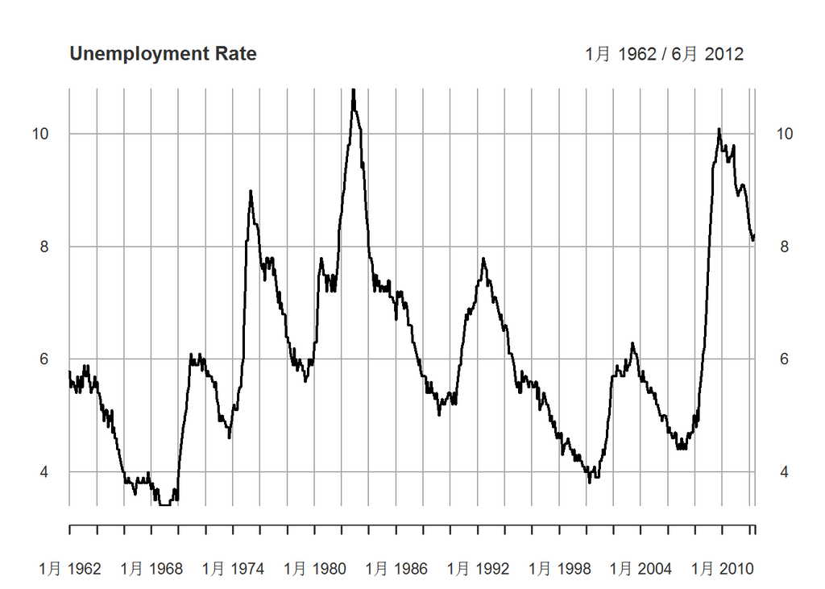

```r
# plot
UnempRate <- xts(x = data$UnemplRate , order.by = data$Date)
plot(UnempRate , xlab =  "Time" , ylab = "Unemployment Rate" , main="Unemployment Rate")
```

## 1.b

**Question**

Estimate an AR(4) model (always include an intercept!) by leastsquares. Report coefficient estimates, robust standard errors, and a one-step point forecast for July 2012.

**Answer**

we find that time series is almost steady after 1st order difference. Through the adf test, we confirm the hypothesis that the time series after differencing is stationary. Then i fit the ARIMA(4 , 1 , 0) (Also the AR(4) after 1st differencing), and give the accurancy, 1 step foward forecasting.

```r
# Get the order of time series
library(forecast)
library(tseries)
ndiffs(UnempRate)  #get the best order of time series, result is 1
```

```
## [1] 1
```

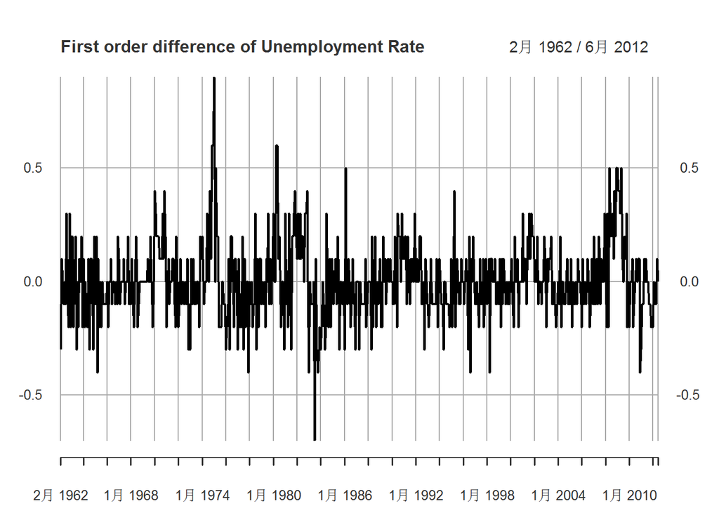

```r
dUnempRate <- diff(UnempRate)
dUnempRate <-dUnempRate[!is.na(dUnempRate)]
plot(dUnempRate , xlab =  "Time" , ylab = "First order difference of Unemployment Rate" , main="First order difference of Unemployment Rate")
```

```r
adf.test(dUnempRate)
```

```
##
##  Augmented Dickey-Fuller Test
##
## data:  dUnempRate
## Dickey-Fuller = -5.6215, Lag order = 8, p-value = 0.01
## alternative hypothesis: stationary
```

```r
fit <- Arima(UnempRate , order = c(4 , 1 , 0))
fit
```

```
## Series: UnempRate
## ARIMA(4,1,0)
##
## Coefficients:
##          ar1     ar2     ar3     ar4
##       0.0264  0.2129  0.1797  0.1466
## s.e.  0.0403  0.0396  0.0396  0.0402
##
## sigma^2 estimated as 0.02683:  log likelihood=237.94
## AIC=-465.88   AICc=-465.78   BIC=-443.85
```

```r
accuracy(fit)
```

```
##                       ME      RMSE       MAE        MPE     MAPE      MASE
## Training set 0.001830562 0.1631066 0.1238605 0.02758516 2.100234 0.1616991
##                      ACF1
## Training set -0.007678321
```

```r
onestepfore <- forecast(fit , 1)
onestepfore
```

```
##        Point Forecast    Lo 80    Hi 80    Lo 95    Hi 95
## Jul 51       8.188662 7.978764 8.398559 7.867651 8.509672
```

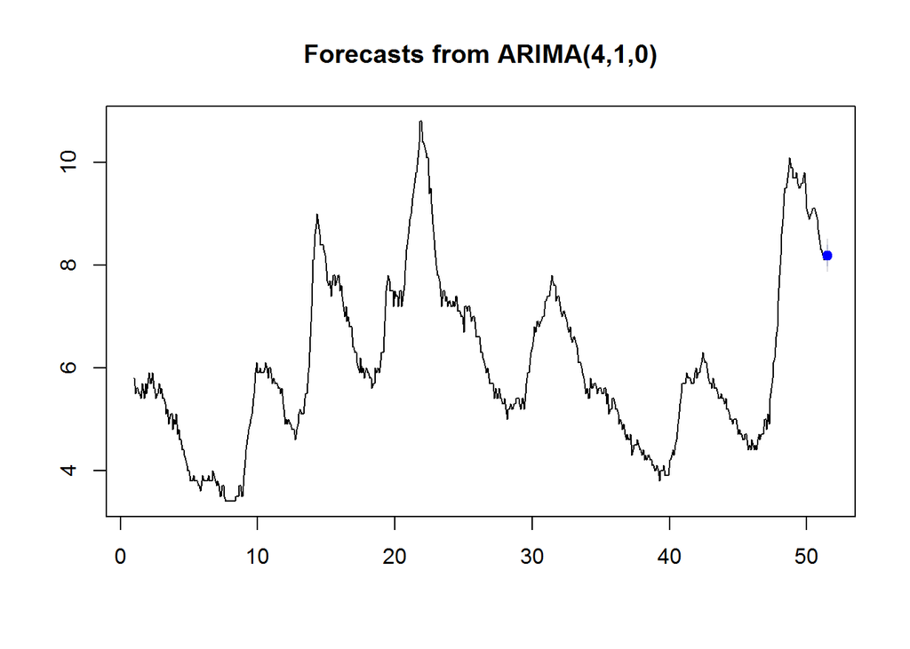

```r
plot(onestepfore)
```

## 1.c

**Question**

Estimate a set of autoregressions (always include an intercept!) by least-squares, AR (1) through AR (24). For each, calculate the Cross Validation information criterion. Also calculate the BIC, AIC, AICc, Mallows, Robust Mallows information criteria. Create a table for your results.

**Answer**

I choose mean MAE as the evaluation index of cross validation, and i get CV.MAE , BIC , AIC , AICC, The mallows , Robust Mallows information criteria are temporarily difficult to get, i will consider them later. Besides, I do not know why the “warnings” occurs in the cross validation, but it doesn’t influence the result, so please ignore the red warnings though it is ugly, and see the result of dataframe directly.

```r
ARModelInfo <- data.frame(CV.MAE = 0  , BIC = 0 , AIC = 0 , AICc = 0 )
# ARModelInfo <- ARModelInfo[ , ]
for (i in 1:24){
  fit <- Arima(UnempRate , order = c(i , 1 , 0))
  # get aicc and bic
  npar <- length(fit$coef) + 1
  nstar <- length(fit$residuals) - fit$arma[6] - fit$arma[7] * fit$arma[5]
  bic <- fit$aic + npar * (log(nstar) - 2)
  aicc <- fit$aic + 2 * npar * (nstar/(nstar - npar - 1) - 1)
  aic <- fit$aic
  accuracy(fit)
  RMSE <- accuracy(fit)[2]  #RMSE

  # calculate the cross validation of ARIMA Model, and here the evaluation choose the MAE
  k <- 60 # minimum data length for fitting a model
  n <- length(UnempRate)
  mae <- matrix(NA , 44 , 12)
  print(i)
  st <- 1962 + k / 12  # (k - 1) / 12 convert month to year, then get the time horizon of train set
  for(j in 1:44)
  {
    xshort <- UnempRate[paste("/" , as.character(st + j - 1) , sep = "")]  #in 1 year once
    xnext <- UnempRate[as.character(as.character(st + j))]  # get 1 year after train set.
    if (i == 9){
      fit <- Arima(xshort, order=c(i , 1 , 0) , method = "ML")
    }
    else{
      fit <- Arima(xshort, order=c(i , 1 , 0) , method = "CSS")
    }
    fcast <- forecast(fit, h=12)
    mae[j,] <- abs(fcast[['mean']]-xnext)
  }
  # plot(1:12, colMeans(mae1), type="l", col=2, xlab="horizon", ylab="MAE")
  # legend("topleft",legend=c("ARIMA"))
  CV.MAE <- mean(mae)

  temp <- c(CV.MAE , bic , aic , aicc)
  ARModelInfo[i , ] <- temp
}
```

```
## [1] 1
```

[output not shown]

[output cut: 32 more lines]

[output not shown]

```
## [1] 2
```

[output not shown]

[output cut: 32 more lines]

[output not shown]

```
## [1] 3
```

[output not shown]

[output cut: 32 more lines]

[output not shown]

```
## [1] 4
```

[output not shown]

[output cut: 32 more lines]

[output not shown]

```
## [1] 5
```

[output not shown]

[output cut: 32 more lines]

[output not shown]

```
## [1] 6
```

[output not shown]

[output cut: 32 more lines]

[output not shown]

```
## [1] 7
```

[output not shown]

[output cut: 32 more lines]

[output not shown]

```
## [1] 8
```

[output not shown]

[output cut: 32 more lines]

[output not shown]

```
## [1] 9
```

[output not shown]

[output cut: 32 more lines]

[output not shown]

```
## [1] 10
```

[output not shown]

[output cut: 32 more lines]

[output not shown]

```
## [1] 11
```

[output not shown]

[output cut: 32 more lines]

[output not shown]

```
## [1] 12
```

[output not shown]

[output cut: 32 more lines]

[output not shown]

```
## [1] 13
```

[output not shown]

[output cut: 32 more lines]

[output not shown]

```
## [1] 14
```

[output not shown]

[output cut: 32 more lines]

[output not shown]

```
## [1] 15
```

[output not shown]

[output cut: 32 more lines]

[output not shown]

```
## [1] 16
```

[output not shown]

[output cut: 32 more lines]

[output not shown]

```
## [1] 17
```

[output not shown]

[output cut: 32 more lines]

[output not shown]

```
## [1] 18
```

[output not shown]

[output cut: 32 more lines]

[output not shown]

```
## [1] 19
```

[output not shown]

[output cut: 32 more lines]

[output not shown]

```
## [1] 20
```

[output not shown]

[output cut: 32 more lines]

[output not shown]

```
## [1] 21
```

[output not shown]

[output cut: 32 more lines]

[output not shown]

```
## [1] 22
```

[output not shown]

[output cut: 32 more lines]

[output not shown]

```
## [1] 23
```

[output not shown]

[output cut: 32 more lines]

[output not shown]

```
## [1] 24
```

[output not shown]

[output cut: 32 more lines]

[output not shown]

```r
ARModelInfo
```

```
##       CV.MAE       BIC       AIC      AICc
## 1  0.4725251 -382.5273 -391.3378 -391.3178
## 2  0.4413986 -421.8432 -435.0589 -435.0189
## 3  0.4242160 -437.1287 -454.7496 -454.6830
## 4  0.4267683 -443.8499 -465.8760 -465.7759
## 5  0.4373725 -439.0419 -465.4732 -465.3328
## 6  0.4440862 -433.3705 -464.2071 -464.0195
## 7  0.4484379 -427.2772 -462.5190 -462.2774
## 8  0.4549694 -421.0183 -460.6654 -460.3629
## 9  0.4482776 -414.6152 -458.6675 -458.2971
## 10 0.4581945 -410.3772 -458.8347 -458.3896
## 11 0.4645289 -405.7000 -458.5628 -458.0358
## 12 0.4553238 -405.5341 -462.8020 -462.1861
## 13 0.4587776 -399.4728 -461.1460 -460.4342
## 14 0.4551416 -397.7529 -463.8313 -463.0164
## 15 0.4571350 -391.5289 -462.0125 -461.0874
## 16 0.4582552 -386.7483 -461.6372 -460.5946
## 17 0.4637089 -380.4155 -459.7096 -458.5424
## 18 0.4681793 -374.1160 -457.8153 -456.5162
## 19 0.4686856 -368.9664 -457.0710 -455.6326
## 20 0.4754833 -363.7583 -456.2681 -454.6832
## 21 0.4760535 -357.5718 -454.4869 -452.7480
## 22 0.4839981 -351.1686 -452.4888 -450.5887
## 23 0.4794984 -344.7920 -450.5175 -448.4486
## 24 0.4615030 -359.1049 -469.2356 -466.9903
```

## 1.d

**Question**

Based on the CV criteria, select an AR model

**Answer**

## 1.e & f

**Question**

Use this model to make a one-step point forecast for July 2012. Report coefficient estimates and robust standard errors.

**Answer**

see belows.

```r
fit <- Arima(UnempRate , order = c(3 , 1 , 0))
fit
```

```
## Series: UnempRate
## ARIMA(3,1,0)
##
## Coefficients:
##          ar1     ar2     ar3
##       0.0539  0.2500  0.1879
## s.e.  0.0400  0.0387  0.0400
##
## sigma^2 estimated as 0.02737:  log likelihood=231.37
## AIC=-454.75   AICc=-454.68   BIC=-437.13
```

```r
accuracy(fit)
```

```
##                       ME      RMSE       MAE        MPE     MAPE      MASE
## Training set 0.002125997 0.1648974 0.1253147 0.02210058 2.124637 0.1635976
##                     ACF1
## Training set -0.02746445
```

```r
onestepfore <- forecast(fit , 1)
onestepfore
```

```
##        Point Forecast    Lo 80    Hi 80    Lo 95    Hi 95
## Jul 51       8.206211 7.994186 8.418236 7.881946 8.530476
```

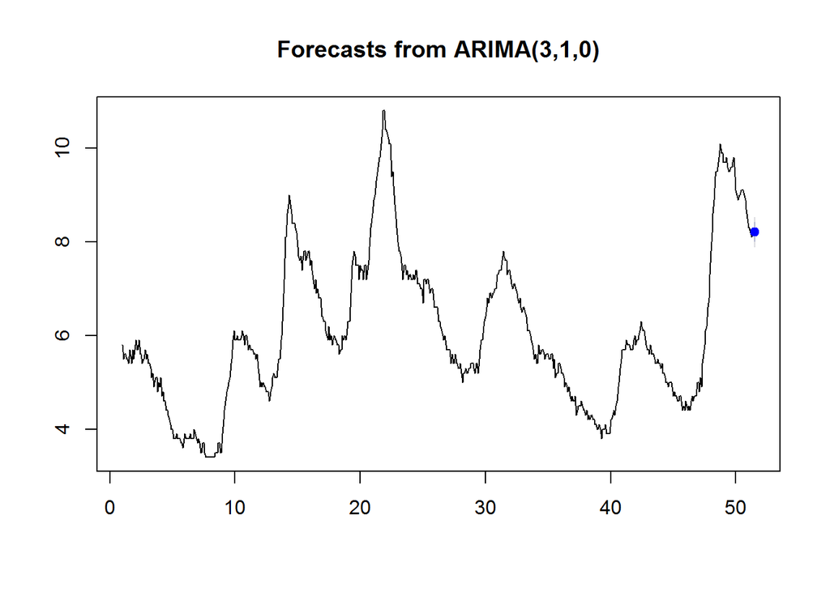

```r
plot(onestepfore)
```

## 1.g & h

**Question**

Now consider the other variables in the data set. After making suitable transformations, include these variables in your model. Using the information criteria, select a forecasting model. Use this forecasting model to make a one-step point forecast for July 2012.

**Answer**

Firstly, I pre whitened the unemployment rate variable with other variables, then i find that the unemployment rate variable is correlated with any other variable. So i do pca first, and get 3 principal components. Then through ccf figure, i find the correlation between unemployment and other variables. Then the arima model with other regressor variables has been fitted. After that, i find the component2 and component3 are not significant, so i set them to be 0. Finally, forecasting has been done based on the model and the model is better than arima(4 , 1 , 0) based on AIC.

```r
# plot every variable's trend to have a rough understanding of them.
head(data)
```

```
##   Year Month UnemplRate TenYearTreaRate ThrMonTreaRate AAArate BAArate
## 1 1962     1        5.8            4.08           2.72    4.42    5.08
## 2 1962     2        5.5            4.04           2.73    4.42    5.07
## 3 1962     3        5.6            3.93           2.72    4.39    5.04
## 4 1962     4        5.6            3.84           2.73    4.33    5.02
## 5 1962     5        5.5            3.87           2.69    4.28    5.00
## 6 1962     6        5.5            3.91           2.73    4.28    5.02
##   Housestarts BuildingPermits IndusprodInd  CPI     Date
## 1        1361            1122      24.6248 31.2 1月 1962
## 2        1278            1194      25.0276 31.2 2月 1962
## 3        1443            1134      25.1619 31.3 3月 1962
## 4        1524            1235      25.2156 31.3 4月 1962
## 5        1483            1142      25.1887 31.4 5月 1962
## 6        1404            1154      25.1350 31.4 6月 1962
```

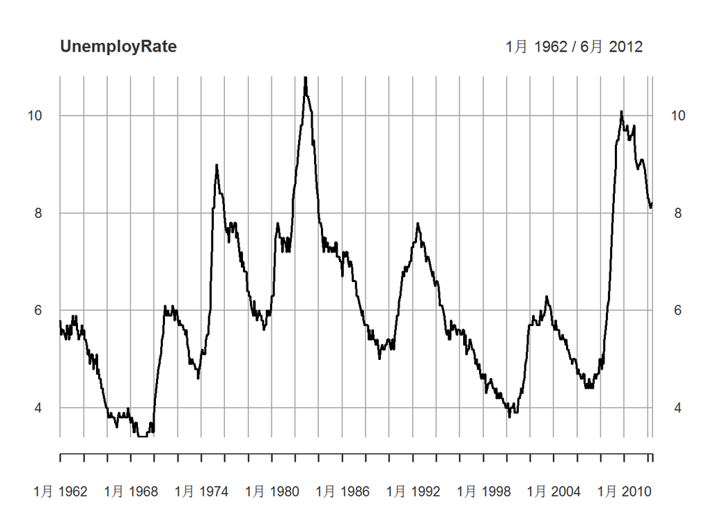

```r
plot(UnempRate , main="UnemployRate")
```

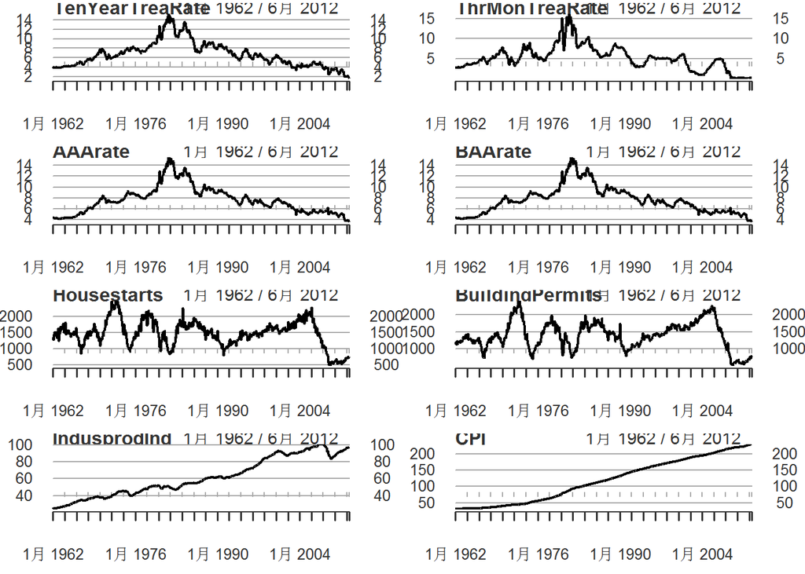

```r
par(mfrow = c(4 , 2))

TenYearTreaRate <- xts(x = data$TenYearTreaRate , order.by = data$Date)
plot(TenYearTreaRate , xlab =  "Time" , ylab = "TenYearTreaRate" , main="TenYearTreaRate")

ThrMonTreaRate <- xts(x = data$ThrMonTreaRate , order.by = data$Date)
plot(ThrMonTreaRate , xlab =  "Time" , ylab = "ThrMonTreaRate" , main="ThrMonTreaRate")

AAArate <- xts(x = data$AAArate , order.by = data$Date)
plot(AAArate , xlab =  "sTime" , ylab = "AAArate" , main="AAArate")

BAArate <- xts(x = data$AAArate , order.by = data$Date)
plot(BAArate , xlab =  "Time" , ylab = "BAArate" , main="BAArate")

Housestarts <- xts(x = data$Housestarts , order.by = data$Date)
plot(Housestarts , xlab =  "Time" , ylab = "Housestarts" , main="Housestarts")

BuildingPermits <- xts(x = data$BuildingPermits , order.by = data$Date)
plot(BuildingPermits , xlab =  "Time" , ylab = "BuildingPermits" , main="BuildingPermits")

IndusprodInd <- xts(x = data$IndusprodInd , order.by = data$Date)
plot(IndusprodInd , xlab =  "Time" , ylab = "IndusprodInd" , main="IndusprodInd")

CPI <- xts(x = data$CPI , order.by = data$Date)
plot(CPI , xlab =  "Time" , ylab = "CPI" , main="CPI")
```

```r
# Pre whitening to see the correlated varialbles
library(TSA)
par(mfrow = c(1 , 1))

# par(mfrow = c(4 , 1))
FiltModel <- arima(UnempRate , order = c(4 , 1 , 0))
CCF1 <- prewhiten(UnempRate , TenYearTreaRate , x.model = FiltModel , ylab="CCF")
```

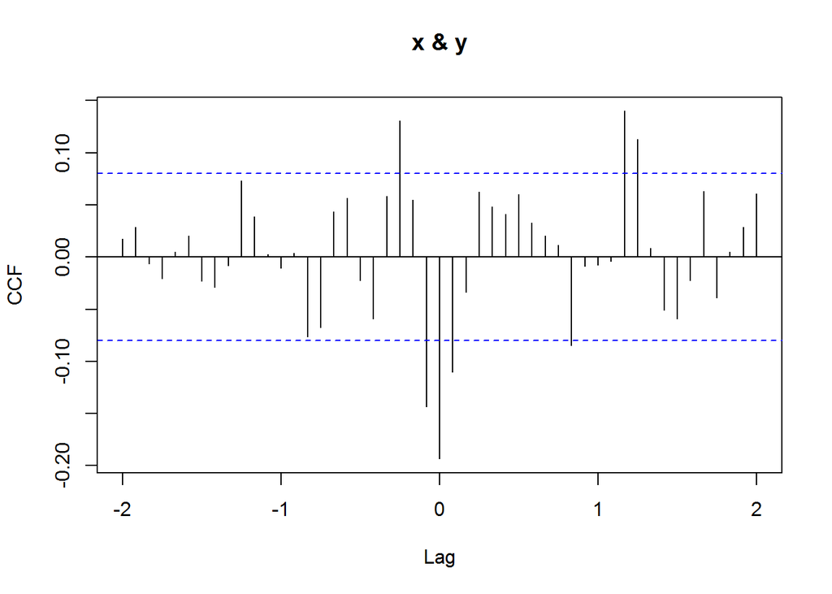

```r
CCF2 <- prewhiten(UnempRate , ThrMonTreaRate , x.model = FiltModel , ylab="CCF")
```

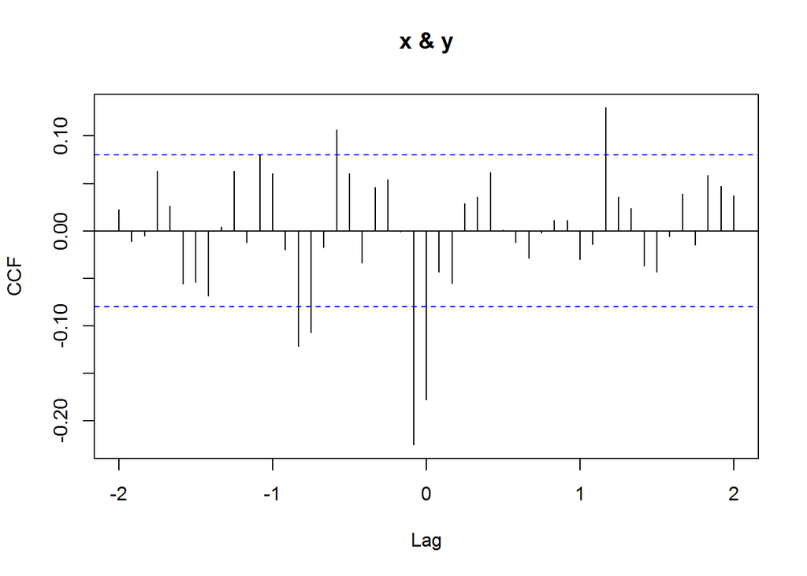

```r
CCF3 <- prewhiten(UnempRate , AAArate , x.model = FiltModel , ylab="CCF")
CCF4 <- prewhiten(UnempRate , BAArate , x.model = FiltModel , ylab="CCF")
```

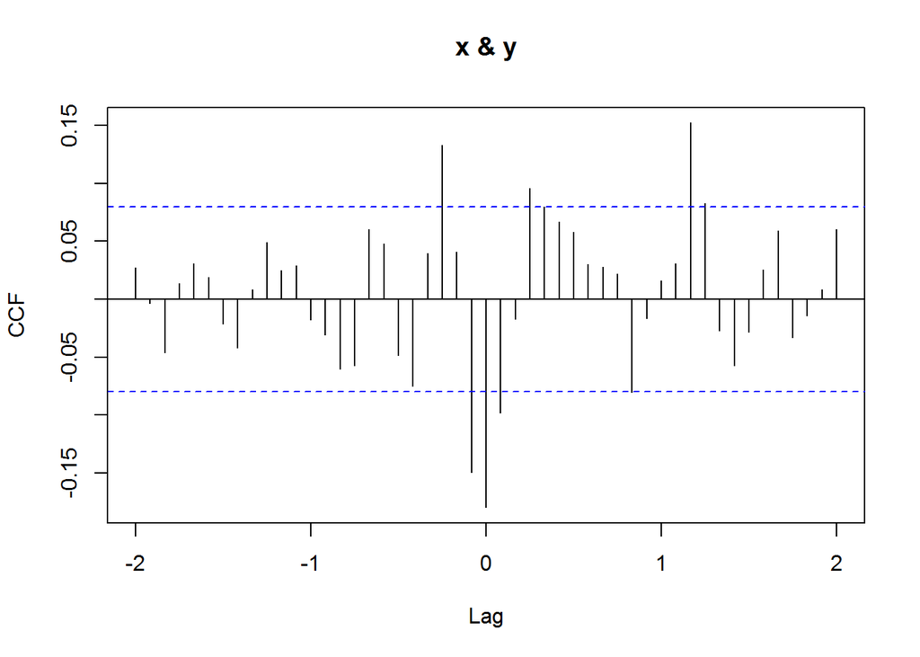

```r
# par(mfrow = c(4 , 1))
CCF5 <- prewhiten(UnempRate , Housestarts , x.model = FiltModel , ylab="CCF")
```

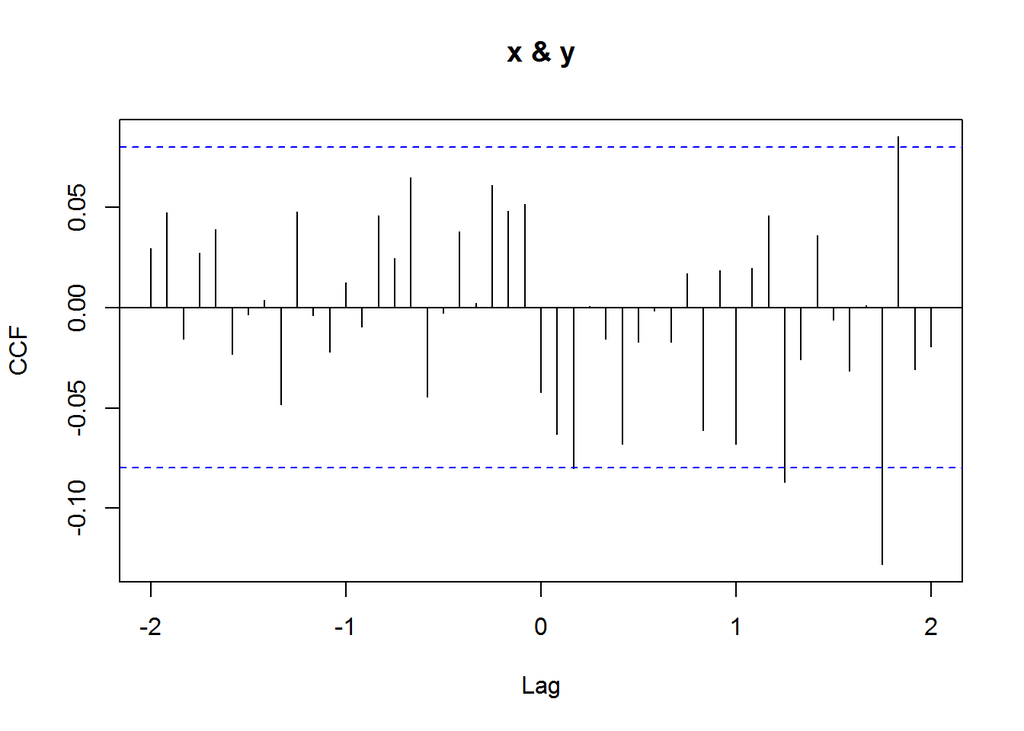

```r
CCF6 <- prewhiten(UnempRate , BuildingPermits , x.model = FiltModel , ylab="CCF")
```

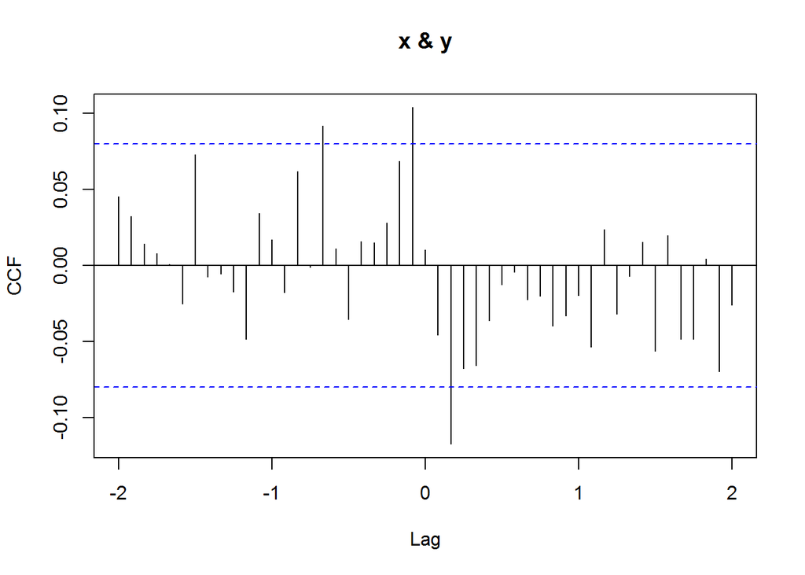

```r
CCF7 <- prewhiten(UnempRate , IndusprodInd , x.model = FiltModel , ylab="CCF")
```

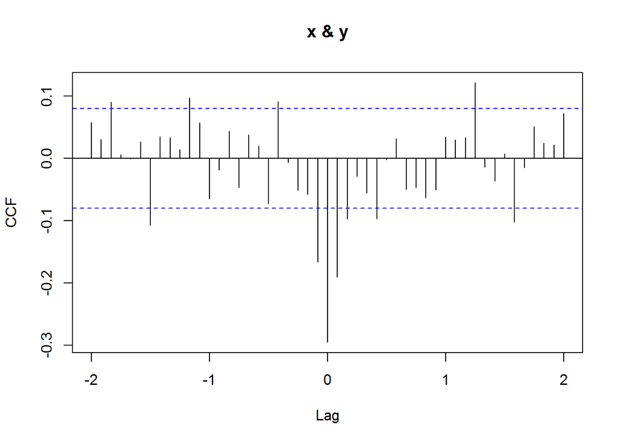

```r
CCF8 <- prewhiten(UnempRate , CPI , x.model = FiltModel , ylab="CCF")
```

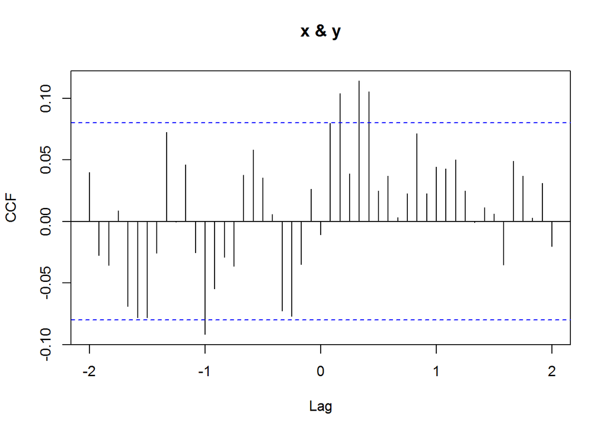

We can find that a lot of variables are correlated to the UnemployRate, but they have high correlation, so i would like to do pca first. Then analyse the ccf between Unemployment and other variables.

```r
library(pls)
#pca.cov = princomp(rtn)
pca = prcomp(data[c("TenYearTreaRate","ThrMonTreaRate","AAArate","BAArate","Housestarts","BuildingPermits","IndusprodInd","CPI")] , center = TRUE, scale. = TRUE)
names(pca)
```

```
## [1] "sdev"     "rotation" "center"   "scale"    "x"
```

```r
summary(pca)
```

```
## Importance of components:
##                           PC1    PC2    PC3     PC4     PC5     PC6
## Standard deviation     2.0221 1.4217 1.2849 0.42564 0.15002 0.14742
## Proportion of Variance 0.5111 0.2527 0.2064 0.02265 0.00281 0.00272
## Cumulative Proportion  0.5111 0.7638 0.9701 0.99279 0.99561 0.99832
##                            PC7     PC8
## Standard deviation     0.09992 0.05856
## Proportion of Variance 0.00125 0.00043
## Cumulative Proportion  0.99957 1.00000
```

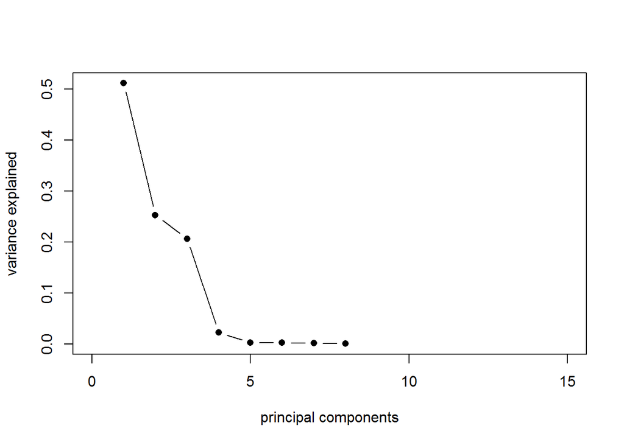

```r
plot(pca$sdev^2/sum(pca$sdev^2), xlim = c(0, 15), type = "b", pch = 16, xlab = "principal components",ylab = "variance explained")
```

```r
PCAComp <- as.data.frame(pca$x)
PCAComp <- PCAComp[c("PC1" , "PC2" , "PC3")]
Com1 <- xts(x = PCAComp[1] , order.by = data$Date)
Com2 <- xts(x = PCAComp[2] , order.by = data$Date)
Com3 <- xts(x = PCAComp[3] , order.by = data$Date)
xregressor =  cbind(as.numeric(Com1[606]) , as.numeric(Com2[606]) , as.numeric(Com3[604]))

CCF1 <- prewhiten(UnempRate , Com1 , x.model = FiltModel , ylab="CCF")
```

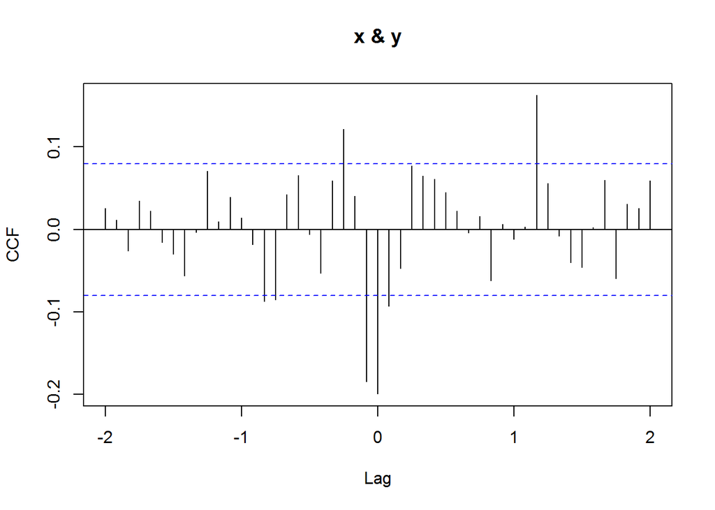

```r
CCF2 <- prewhiten(UnempRate , Com2 , x.model = FiltModel , ylab="CCF")
```

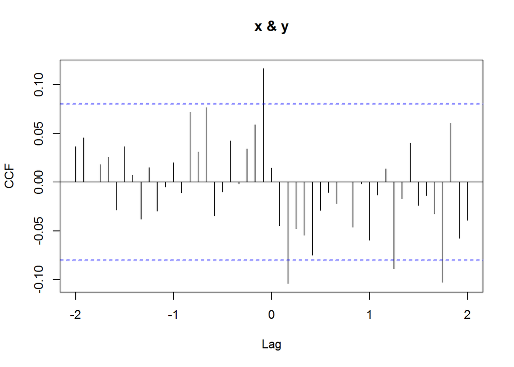

```r
CCF3 <- prewhiten(UnempRate , Com3 , x.model = FiltModel , ylab="CCF")
```

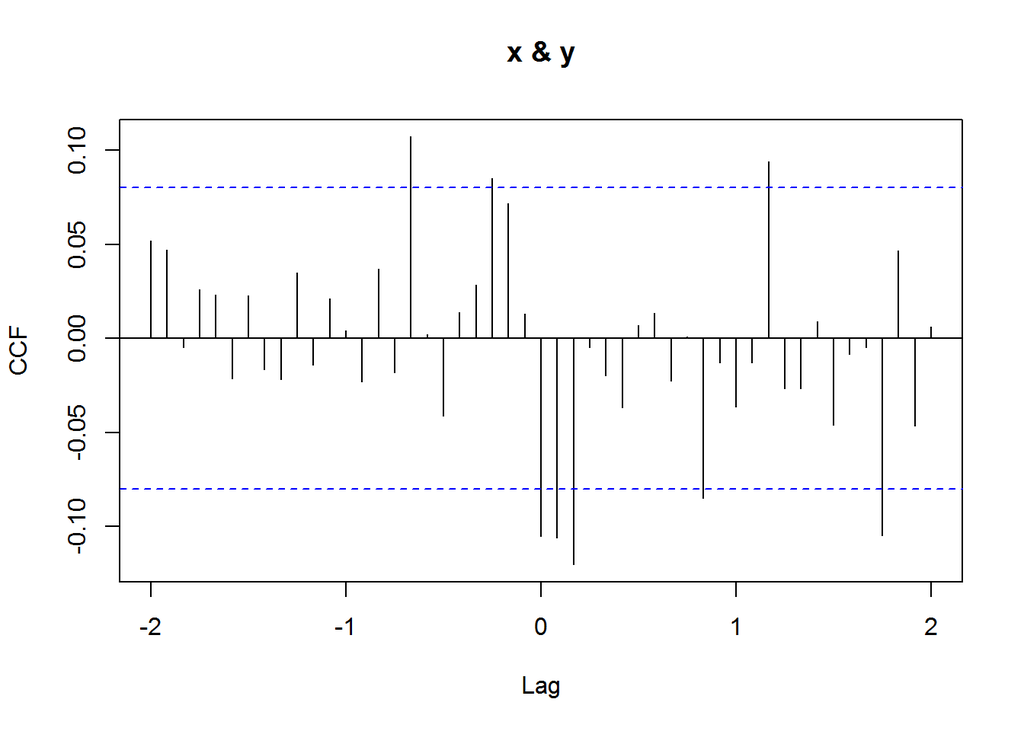

```r
Com1 <- lag(Com1 , k = 1)
Com2 <- lag(Com2 , k = 1)
Com3 <- lag(Com3 , k = 3)
# Com2 <- Com2[-1]
# Com1 <- Com1[-1]
# Com3 <- Com3[-1]
# UnempRate2 <- UnempRate[-1]
Xvari <- cbind(Com1, Com2, Com3)
head(Xvari)
```

```
##                PC1       PC2       PC3
## 1月 1962        NA        NA        NA
## 2月 1962 -1.312639 0.8668983        NA
## 3月 1962 -1.335554 0.8377050        NA
## 4月 1962 -1.335817 1.0202310 -2.756761
## 5月 1962 -1.330587 1.3049397 -2.727942
## 6月 1962 -1.367583 1.1084317 -2.689035
```

```r
# fit the Multivariate time series model
MulArimaMod <- Arima(UnempRate , order = c(4 , 1 , 0) ,
                     xreg = Xvari )
MulArimaMod
```

```
## Series: UnempRate
## Regression with ARIMA(4,1,0) errors
##
## Coefficients:
##           ar1     ar2     ar3     ar4      PC1      PC2      PC3
##       -0.0028  0.2031  0.1901  0.1693  -0.0905  -0.0355  -0.0321
## s.e.   0.0417  0.0398  0.0395  0.0411   0.0356   0.0252   0.0475
##
## sigma^2 estimated as 0.02658:  log likelihood=241.05
## AIC=-466.1   AICc=-465.85   BIC=-430.89
```

```r
accuracy(MulArimaMod)
```

```
##                      ME      RMSE       MAE        MPE     MAPE      MASE
## Training set 0.00175024 0.1619447 0.1233263 0.02728095 2.095807 0.1610018
##                     ACF1
## Training set -0.01056275
```

```r
# Set component2 and component3's coefficients to be 0, then fit the model again.
MulArimaMod <- Arima(UnempRate , order = c(4 , 1 , 0) ,
                     xreg = Xvari  , fixed = c(NA , NA , NA , NA , NA , 0 , 0))
MulArimaMod
```

```
## Series: UnempRate
## Regression with ARIMA(4,1,0) errors
##
## Coefficients:
##          ar1     ar2     ar3     ar4      PC1  PC2  PC3
##       0.0084  0.2017  0.1893  0.1688  -0.0864    0    0
## s.e.  0.0407  0.0398  0.0395  0.0411   0.0357    0    0
##
## sigma^2 estimated as 0.02658:  log likelihood=240
## AIC=-468.01   AICc=-467.86   BIC=-441.6
```

```r
accuracy(MulArimaMod)
```

```
##                      ME      RMSE       MAE        MPE     MAPE      MASE
## Training set 0.00174286 0.1622255 0.1236098 0.03061984 2.098652 0.1613719
##                     ACF1
## Training set -0.01023222
```

```r
onestepfore2 <- forecast(MulArimaMod , xreg = xregressor , h = 1)
onestepfore2
```

```
##        Point Forecast    Lo 80    Hi 80    Lo 95    Hi 95
## Jul 51       8.190779 7.981836 8.399721 7.871229 8.510329
```

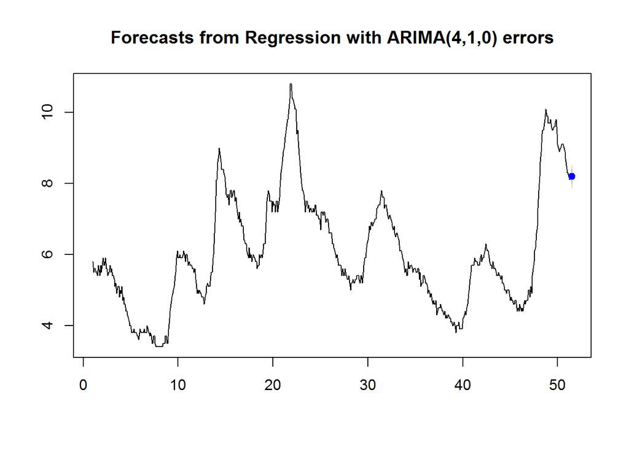

```r
plot(onestepfore2)
```

# Second Task

## 2.a

**Question**

The ‘glmnet’ function, by default, internally scales the predictor variables so that they will have standard deviation 1, before solving the ridge regression or lasso problems. This is a result of its default setting ‘tandardize=TRUE’. Explain why such scaling is appropriate in our particular application.

**Answer**

Because ridge regression and lasso are based on the least square plus a penalty term, Penalty term is added to limit the size of the parameter. Therefore, the dimension of parameters will affect the size of penalty terms, so it needs to be standardized. So that every parameter can contribute to the penalty term. Besides, sometimes we will meet the problem that one variable is pretty big comparing to other variables, then it might cause numerical calculation problems

## 2.b

**Question**

**Answer**

see belows. *note:the code in this chunk need the function that i defined.*

```r
library(glmnet)
```

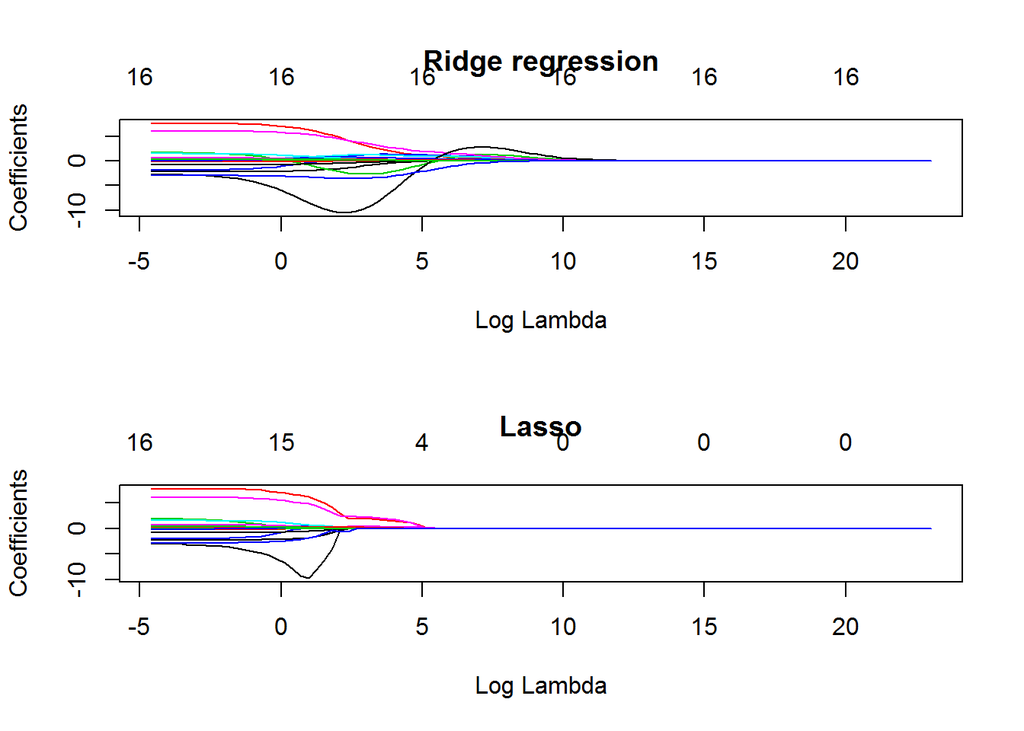

```r
library(ISLR)
grid <- 10^seq(10 , -2 , length = 100)
df.Hitters = sqldf("select * from Hitters where Salary > 0")
rid.mod = glmnet(as.matrix(df.Hitters[c("AtBat" , "Hits" , "HmRun" , "Runs" , "RBI" , "Walks" , "Years" , "CAtBat" , "CHits" , "CHmRun" , "CRuns" , "CRBI" , "CWalks" , "PutOuts" , "Assists" , "Errors")]) , df.Hitters$Salary , lambda=grid , alpha=0)
las.mod = glmnet(as.matrix(df.Hitters[c("AtBat" , "Hits" , "HmRun" , "Runs" , "RBI" , "Walks" , "Years" , "CAtBat" , "CHits" , "CHmRun" , "CRuns" , "CRBI" , "CWalks" , "PutOuts" , "Assists" , "Errors")]) , df.Hitters$Salary , lambda=grid , alpha=1)
par(mfrow = c(2 , 1))
plot(rid.mod , xvar = "lambda"  , main = "Ridge regression")
plot(las.mod , xvar = "lambda" , main = "Lasso")
```

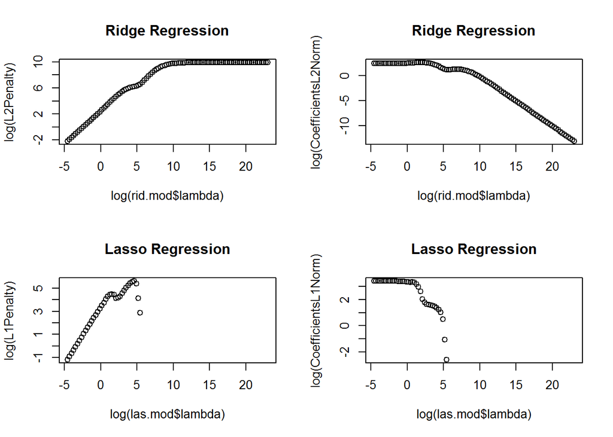

```r
par(mfrow = c(2 , 2))
Coefficients <- rid.mod$beta
CoefficientsL2Norm <- apply(Coefficients , 2 , L2Norm)
L2Penalty <- CoefficientsL2Norm * rid.mod$lambda
plot(log(rid.mod$lambda) , log(L2Penalty) , main = "Ridge Regression")
plot(log(rid.mod$lambda) , log(CoefficientsL2Norm) , main = "Ridge Regression")

Coefficients <- las.mod$beta
CoefficientsL1Norm <- apply(Coefficients , 2 , L1Norm)
L1Penalty <- CoefficientsL1Norm * las.mod$lambda
plot(log(las.mod$lambda) , log(L1Penalty) , main = "Lasso Regression")
plot(log(las.mod$lambda) , log(CoefficientsL1Norm) , main = "Lasso Regression")
```

## 2.c

**Question**

Verify that, for a very small value of ??; both the ridge regression and lasso estimates are very close to the least squares estimate. Also verify that, for a very large value of ??; both the ridge regression and lasso estimates approach 0 in all components (except the intercept, which is not penalized by default).

**Answer**

I print 3 models’ coefficients, we can find they are almost the same. And we can find from the figure below, the coefficients become 0 when lambda get pretty bigger.

```r
par(mfrow = c(2 , 1))
ols.mod <- lm(Salary~AtBat + Hits + HmRun + Runs + RBI + Walks + Years + CAtBat + CHits + CHmRun + CRuns + CRBI + CWalks + PutOuts + Assists + Errors , data = df.Hitters)
print("ols's coefficients")
```

```
## [1] "ols's coefficients"
```

```r
ols.mod$coefficients
```

```
##  (Intercept)        AtBat         Hits        HmRun         Runs
## 126.10552646  -2.20302192   7.82776155   2.16354600  -2.09956715
##          RBI        Walks        Years       CAtBat        CHits
##  -0.02291591   6.15106073  -2.59236836  -0.17627608   0.06976160
##       CHmRun        CRuns         CRBI       CWalks      PutOuts
##  -0.23308812   1.61005004   0.80142766  -0.79394138   0.29457344
##      Assists       Errors
##   0.38399530  -2.87871429
```

```r
print("")
```

```
## [1] ""
```

```r
print("ridge regression's coefficients where lambda is 0.01")
```

```
## [1] "ridge regression's coefficients where lambda is 0.01"
```

```r
rid.mod$beta[,100]
```

```
##      AtBat       Hits      HmRun       Runs        RBI      Walks
## -2.1928183  7.6708931  1.7075477 -1.8805629  0.1261327  6.1047511
##      Years     CAtBat      CHits     CHmRun      CRuns       CRBI
## -2.7312992 -0.1829853  0.1668432  0.0371916  1.5060155  0.6868742
##     CWalks    PutOuts    Assists     Errors
## -0.7732316  0.2946148  0.3874085 -2.9548462
```

```r
print("")
```

```
## [1] ""
```

```r
print("Lasso's coefficients where lambda is 0.01")
```

```
## [1] "Lasso's coefficients where lambda is 0.01"
```

```r
las.mod$beta[,100]
```

```
##       AtBat        Hits       HmRun        Runs         RBI       Walks
## -2.21469824  7.81722910  1.95411638 -2.02439475  0.05233650  6.14965314
##       Years      CAtBat       CHits      CHmRun       CRuns        CRBI
## -3.05455455 -0.16860295  0.07465736 -0.14083443  1.57513211  0.75776246
##      CWalks     PutOuts     Assists      Errors
## -0.79327590  0.29494863  0.38136849 -2.88599959
```

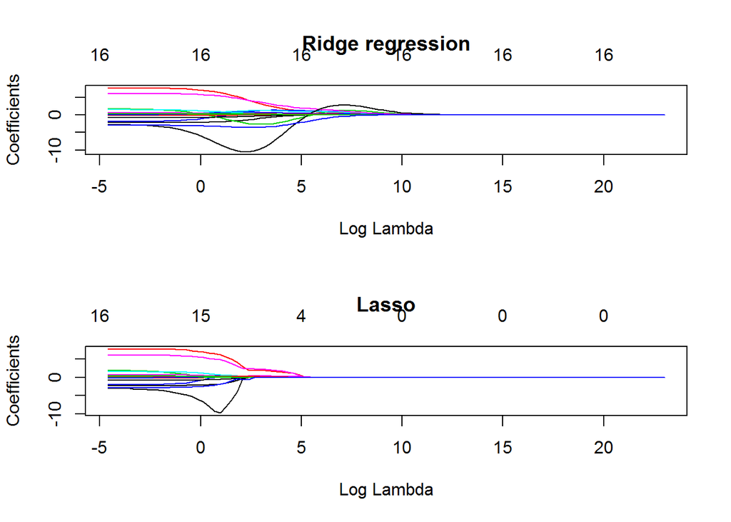

```r
plot(rid.mod , xvar = "lambda"  , main = "Ridge regression")
plot(las.mod , xvar = "lambda" , main = "Lasso")
```

## 2.d

**Question**

For each of the ridge regression and lasso models, perform 5 -fold cross-validation to determine the best value of $\lambda$. Report the results from both the usual rule, and the one standard error rule for choosing $\lambda$: You can either perform this cross-validation procedure manually, or use the “cv.glmnet” function. Either way, produce a plot of the cross-validation error curve as a function of ??; for both the ridge and lasso models.

**Answer**

see belows

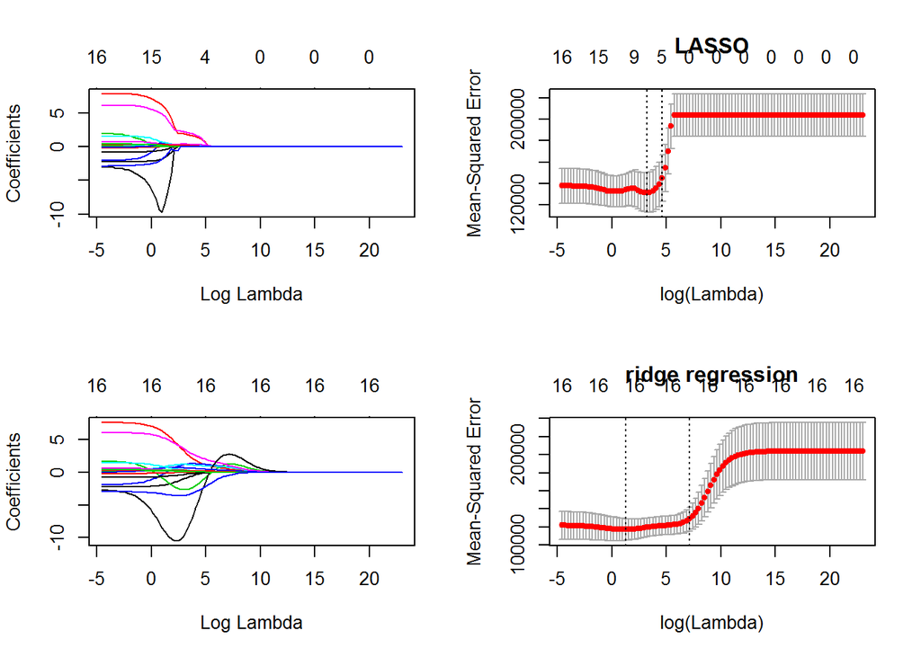

```r
# 10-fold Cross validation for each alpha = 0, 0.1, ... , 0.9, 1.0
fit.lasso.cv <- cv.glmnet(as.matrix(df.Hitters[c("AtBat" , "Hits" , "HmRun" , "Runs" , "RBI" , "Walks" , "Years" , "CAtBat" , "CHits" , "CHmRun" , "CRuns" , "CRBI" , "CWalks" , "PutOuts" , "Assists" , "Errors")]) , df.Hitters$Salary , lambda = grid , alpha = 1 , family = "gaussian" ,  nfolds = 5)

fit.rid.cv <- cv.glmnet(as.matrix(df.Hitters[c("AtBat" , "Hits" , "HmRun" , "Runs" , "RBI" , "Walks" , "Years" , "CAtBat" , "CHits" , "CHmRun" , "CRuns" , "CRBI" , "CWalks" , "PutOuts" , "Assists" , "Errors")]) , df.Hitters$Salary , lambda = grid , alpha = 0 , family = "gaussian" ,  nfolds = 5)
# Plot solution paths:
par(mfrow=c(2,2))
# For plotting options, type '?plot.glmnet' in R console
plot(las.mod, xvar="lambda")
plot(fit.lasso.cv, main="LASSO")

plot(rid.mod, xvar="lambda")
plot(fit.rid.cv, main="ridge regression")
```

```r
print("lasso's lambda of min cv error and lambda based on the one standard error rule")
```

```
## [1] "lasso's lambda of min cv error and lambda based on the one standard error rule"
```

```r
fit.lasso.cv$lambda.min
```

```
## [1] 24.77076
```

```r
fit.lasso.cv$lambda.1se
```

```
## [1] 100
```

```r
print("ridge regression's lambda of min cv error and lambda based on the one standard error rule")
```

```
## [1] "ridge regression's lambda of min cv error and lambda based on the one standard error rule"
```

```r
fit.rid.cv$lambda.min
```

```
## [1] 3.511192
```

```r
fit.rid.cv$lambda.1se
```

```
## [1] 1232.847
```

## 2.e

**Question**

From the last part, you should have computed 4 values of the tuning parameter:
$$\lambda_{min}^{ridge},\lambda_{lse}^{ridge},\lambda_{min}^{lasso},\lambda_{lse}^{lasso}$$
These are the results of running 5-fold cross-validation on each of the ridge and lasso models, and using the usual rule (min) or the one standard error rule (1se) to select $\lambda$. Now, using the predict function, with type: “coef”, and the ridge and lasso models fit in part (b), report the coefficient estimates at the appropriate values of $\lambda$. That is, you will report two coefficient vectors coming from ridge regression with $\lambda = \lambda_{min}^{ridge} and \lambda = \lambda_{1se}^{ridge}$, and likewise for the lasso. How do the coefficient estimates from the usual rule compare to those from the one standard error rule? How do the ridge estimates compare to those from the lasso?

**Answer**

see belows. lambda_min is value of lambda that gives minimum cvm where cvm is the mean cross-validated error. So the best model chosen by the lambda_min is the model that has the minimum generalization error. lambda_1se is the largest value of lambda such that error is within 1 standard error of the minimum. So the best model chosen by the lambda_1se is the model that has a good performance but not the best in the test set, in the meanwhile, the model is as much simple as possible. Ridge regression coefficents estimates compare to those from the lasso are much more complex, wuich means lasso model has less parameters that not euqal to 0.

```r
print("ridge regression's 1se lambda:")
```

```
## [1] "ridge regression's 1se lambda:"
```

```r
fit.rid.cv$lambda.1se
```

```
## [1] 1232.847
```

```r
print("ridge regression's min cv_erroe lambda:")
```

```
## [1] "ridge regression's min cv_erroe lambda:"
```

```r
fit.rid.cv$lambda.min
```

```
## [1] 3.511192
```

```r
print("Lasso's 1se lambda:")
```

```
## [1] "Lasso's 1se lambda:"
```

```r
fit.lasso.cv$lambda.1se
```

```
## [1] 100
```

```r
print("Lasso's min cv_erroe lambda:")
```

```
## [1] "Lasso's min cv_erroe lambda:"
```

```r
fit.lasso.cv$lambda.min
```

```
## [1] 24.77076
```

```r
print("ridge regression's coefficients of 1se lambda:")
```

```
## [1] "ridge regression's coefficients of 1se lambda:"
```

```r
rid.mod$beta[ , rid.mod$lambda == fit.rid.cv$lambda.1se]
```

```
##        AtBat         Hits        HmRun         Runs          RBI
##  0.110988185  0.534246094  1.284880666  0.816371303  0.774803881
##        Walks        Years       CAtBat        CHits       CHmRun
##  1.103975914  2.821918069  0.009804451  0.039741721  0.288953757
##        CRuns         CRBI       CWalks      PutOuts      Assists
##  0.079816668  0.082403062  0.072111678  0.087878153  0.012373514
##       Errors
## -0.368178866
```

```r
print("ridge regression's coefficients of min cv error lambda:")
```

```
## [1] "ridge regression's coefficients of min cv error lambda:"
```

```r
rid.mod$beta[ , rid.mod$lambda == fit.rid.cv$lambda.min]
```

```
##       AtBat        Hits       HmRun        Runs         RBI       Walks
## -1.86062453  6.04444050 -1.18354749 -0.06281154  0.94209133  5.22523142
##       Years      CAtBat       CHits      CHmRun       CRuns        CRBI
## -9.17161918 -0.07346844  0.19016270  0.71093348  0.83498554  0.35081472
##      CWalks     PutOuts     Assists      Errors
## -0.59374100  0.29112859  0.31355686 -3.36046881
```

```r
print("Lasso's coefficients of 1se lambda:")
```

```
## [1] "Lasso's coefficients of 1se lambda:"
```

```r
las.mod$beta[ , las.mod$lambda == fit.lasso.cv$lambda.1se]
```

```
##       AtBat        Hits       HmRun        Runs         RBI       Walks
## 0.000000000 1.135665416 0.000000000 0.000000000 0.000000000 1.181370449
##       Years      CAtBat       CHits      CHmRun       CRuns        CRBI
## 0.000000000 0.000000000 0.000000000 0.000000000 0.115017553 0.309842801
##      CWalks     PutOuts     Assists      Errors
## 0.000000000 0.003539267 0.000000000 0.000000000
```

```r
print("Lasso's coefficients of min cv error lambda:")
```

```
## [1] "Lasso's coefficients of min cv error lambda:"
```

```r
las.mod$beta[ , las.mod$lambda == fit.lasso.cv$lambda.min]
```

```
##     AtBat      Hits     HmRun      Runs       RBI     Walks     Years
## 0.0000000 1.8556886 0.0000000 0.0000000 0.0000000 2.1825350 0.0000000
##    CAtBat     CHits    CHmRun     CRuns      CRBI    CWalks   PutOuts
## 0.0000000 0.0000000 0.0000000 0.2306359 0.3715463 0.0000000 0.2013108
##   Assists    Errors
## 0.0000000 0.0000000
```

## 2.f

**Question**

Suppose that you were coaching a young baseball player who wanted to strike it rich in the major leagues. What handful of attributes would you tell this player to focus on? (That is, how to measure variable importance?)

**Answer**

# Third Task

## 3.a

**Question**

For the “sp500price” data set we have used in class, you need to specify an appropriate form of GARCH model for the return of ‘sp500’ with information criterion method and rolling estimation method. For rolling method, the window size is 2500 and the estimation is implemented every 100 observations (To save the computation cost, moving window method is recommended.)

**Answer**

We can get the conclusion that Model5 is the best model among the 6 models, while Model1 is also good.

Firstly , have a rough understanding of the sp500ret data, then I find arima(1 , 0 , 4) would be a good choice to fit the data.

```r
library(PerformanceAnalytics)
par(mfrow = c(3 , 1))
load(paste(FileRoute , "sp500prices.Rdata" , sep = ""))
str(sp500prices)
```

```
## An 'xts' object on 1989-01-03/2017-12-29 containing:
##   Data: num [1:7308, 1] 275 279 280 281 281 ...
##  - attr(*, "dimnames")=List of 2
##   ..$ : NULL
##   ..$ : chr "GSPC.Adjusted"
##   Indexed by objects of class: [Date] TZ: UTC
##   xts Attributes:
## List of 2
##  $ src    : chr "yahoo"
##  $ updated: POSIXct[1:1], format: "2018-08-28 22:39:56"
```

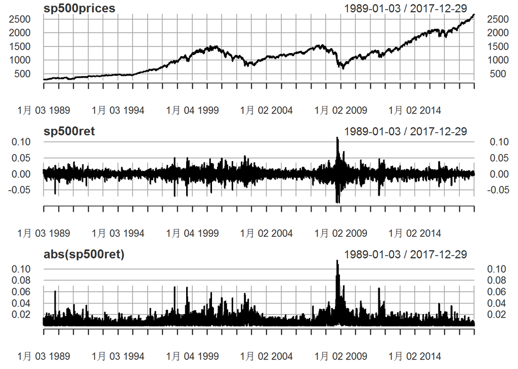

```r
# Plot daily S&P 500 prices
plot(sp500prices)
# Compute daily returns
sp500ret <- CalculateReturns(sp500prices)
# Plot daily returns
plot(sp500ret)
plot(abs(sp500ret))
```

```r
# Compute the daily standard deviation for the complete sample
sd(na.omit(sp500ret))
```

```
## [1] 0.01099357
```

```r
sp500ret = sp500ret[-1]
sd(sp500ret[-1])
```

```
## [1] 0.01099299
```

```r
# Compute the annualized volatility for the complete sample
sqrt(252) * sd(sp500ret)
```

```
## [1] 0.1745175
```

```r
# Compute the annualized deviation for the year 2009
sqrt(252) * sd(sp500ret["2009"])
```

```
## [1] 0.2728502
```

```r
# Compute the annualized standard deviation for the year 2017
sqrt(252) * sd(sp500ret["2017"])
```

```
## [1] 0.06685664
```

```r
adf.test(sp500ret)
```

```
##
##  Augmented Dickey-Fuller Test
##
## data:  sp500ret
## Dickey-Fuller = -19.555, Lag order = 19, p-value = 0.01
## alternative hypothesis: stationary
```

```r
Box.test(sp500ret , lag = 6  , type = "Ljung-Box")
```

```
##
##  Box-Ljung test
##
## data:  sp500ret
## X-squared = 49.292, df = 6, p-value = 6.517e-09
```

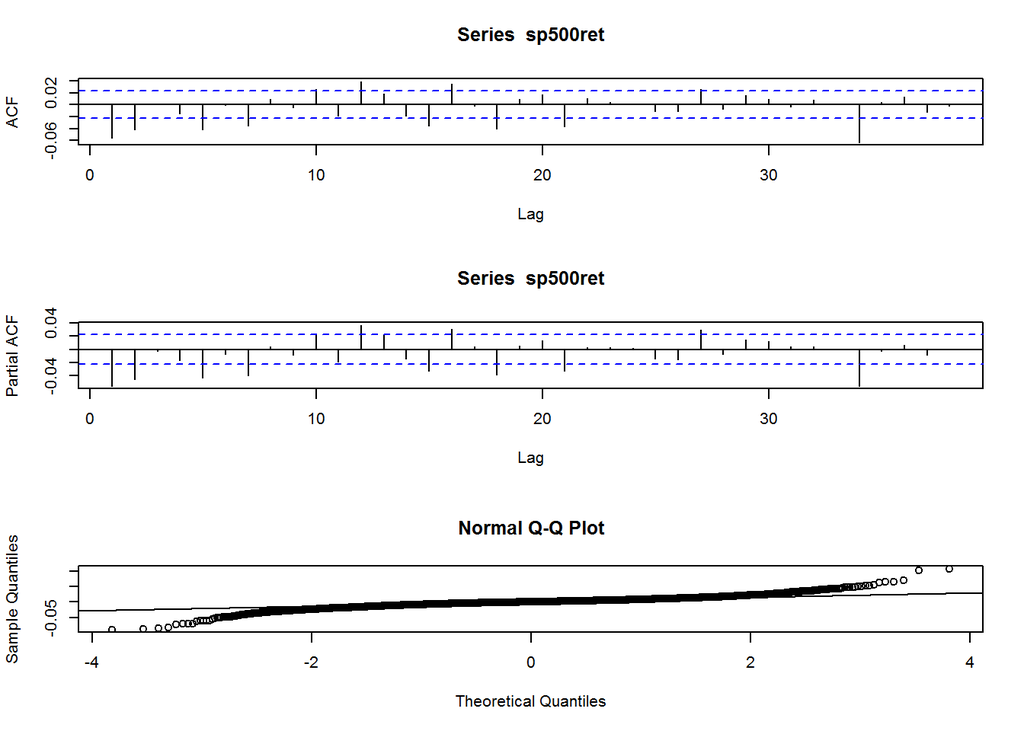

```r
Acf(sp500ret)
Pacf(sp500ret)
fit <- arima(sp500ret , order = c(1 , 0 , 4))
qqnorm(fit$residuals)
qqline(fit$residuals)
```

```
##
##  Box-Ljung test
##
## data:  fit$residuals
## X-squared = 5.7399, df = 6, p-value = 0.453
```

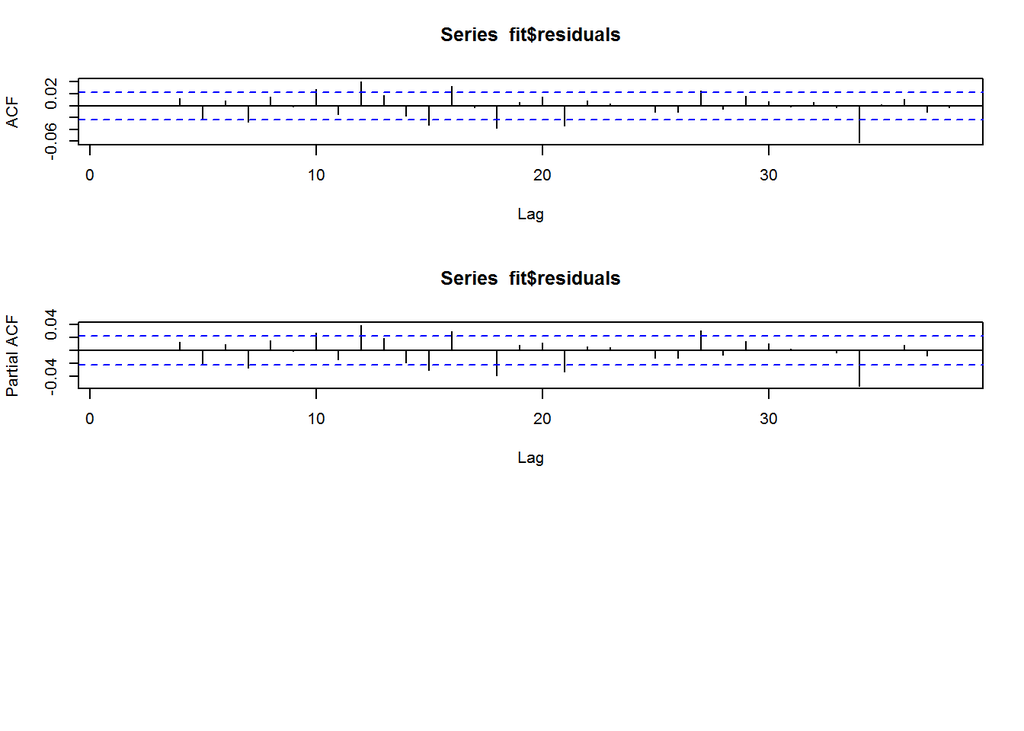

```r
Acf(fit$residuals)
Pacf(fit$residuals)
Box.test(fit$residuals , lag = 6  , type = "Ljung-Box")
```

Secondly, find the best model.

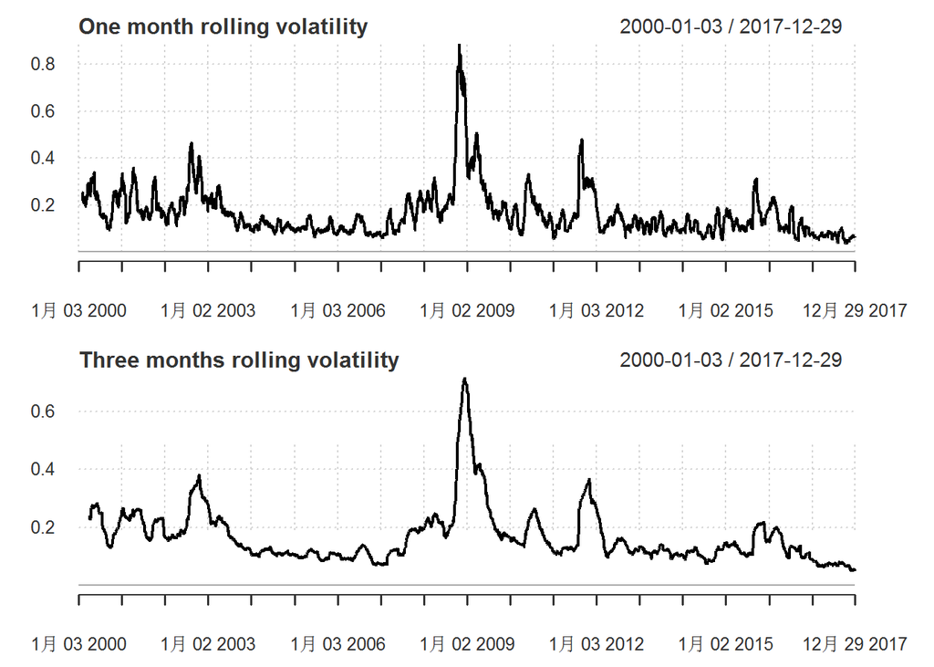

```r
# Showing two plots on the same figure
par(mfrow=c(2,1))

# Compute the rolling 1 month estimate of annualized volatility
chart.RollingPerformance(R = sp500ret["2000::2017"], width = 22,
     FUN = "sd.annualized", scale = 252, main = "One month rolling volatility")

# Compute the rolling 3 months estimate of annualized volatility
chart.RollingPerformance(R = sp500ret["2000::2017"], width = 66,
     FUN = "sd.annualized", scale = 252, main = "Three months rolling volatility")
```

```r
# Model selection
#First Model
library(rugarch)
# Specify a standard GARCH model with constant mean
tgarchspec0 <- ugarchspec(mean.model = list(armaOrder = c(0,0)),
                 variance.model = list(model ="sGARCH",garchOrder = c(1, 1)),
                 distribution.model = "norm")

garchroll0 <- ugarchroll(tgarchspec0, data = sp500ret, n.start = 2500,
refit.window = "moving", refit.every = 100)
preds0 <- as.data.frame(garchroll0)
e0 <- preds0$Realized - preds0$Mu
d0 <- e0^2 - preds0$Sigma^2
predaccu0 <- mean(d0^2)

# second model
tgarchspec1 <- ugarchspec(mean.model = list(armaOrder = c(1,0)),
variance.model = list(model = "gjrGARCH"),
distribution.model = "sstd")

garchroll1 <- ugarchroll(tgarchspec1, data = sp500ret , n.start = 2500,
refit.window = "moving", refit.every = 100)

preds1 <- as.data.frame(garchroll1)
e1 <- preds1$Realized - preds1$Mu
d1 <- e1^2 - preds1$Sigma^2
predaccu1 <- mean(d1^2)

# third model
tgarchspec2 <- ugarchspec(mean.model = list(armaOrder = c(1,0)),
variance.model = list(model = "gjrGARCH"),
distribution.model = "std")

garchroll2 <- ugarchroll(tgarchspec2, data = sp500ret, n.start = 2500,
refit.window = "moving", refit.every = 100)

preds2 <- as.data.frame(garchroll2)
e2 <- preds2$Realized - preds2$Mu
d2 <- e2^2 - preds2$Sigma^2
predaccu2 <- mean(d2^2)

# forth model
tgarchspec3 <- ugarchspec(mean.model = list(armaOrder = c(1,0)),
variance.model = list(model = "sGARCH"),
distribution.model = "std")

garchroll3 <- ugarchroll(tgarchspec3, data = sp500ret, n.start = 2500,
refit.window = "moving", refit.every = 100)

preds3 <- as.data.frame(garchroll3)
e3 <- preds3$Realized - preds3$Mu
d3 <- e3^2 - preds3$Sigma^2
predaccu3 <- mean(d3^2)

# fifth model
tgarchspec4 <- ugarchspec(mean.model = list(armaOrder = c(1,0)),
variance.model = list(model = "gjrGARCH"),
distribution.model = "sstd")

garchroll4 <- ugarchroll(tgarchspec4, data = sp500ret , n.start = 2500,
refit.window = "moving", refit.every = 1000)

preds4 <- as.data.frame(garchroll4)
e4 <- preds4$Realized - preds4$Mu
d4 <- e4^2 - preds4$Sigma^2
predaccu4 <- mean(d4^2)

# sixth model
tgarchspec5 <- ugarchspec(mean.model = list(armaOrder = c(1,4)),
variance.model = list(model = "gjrGARCH"),
distribution.model = "sstd")

garchroll5 <- ugarchroll(tgarchspec5, data = sp500ret , n.start = 2500,
refit.window = "moving", refit.every = 100)

preds5 <- as.data.frame(garchroll5)
e5 <- preds5$Realized - preds5$Mu
d5 <- e5^2 - preds5$Sigma^2
predaccu5 <- mean(d5^2)


predictionaccurancy <- data.frame(Model0 = predaccu0 , Model1=predaccu1 , Model2 = predaccu2 , Model3 = predaccu3 , Model4 = predaccu4 , Model5 = predaccu5)
predictionaccurancy
```

```
##         Model0       Model1       Model2       Model3      Model4
## 1 1.748879e-07 1.625219e-07 1.631842e-07 1.727203e-07 1.63431e-07
##         Model5
## 1 1.542768e-07
```

## 3.b

**Question**

Forward looking risk management uses the predicted quantiles from the GARCH estimation. Using “ugarchroll” method to estimate the best GARCH model you have obtained from (a) by rolling method to compute $VaRt(\alpha)$ for $\alpha$ = 0.05. The setting of rolling estimation is the same as (a).

**Answer**

see belows note:It seems that the VaR is positive accoring to the fomular $VaR_t(\alpha)=\mu+\sigma_{t|t-1}*F^{-1}(\alpha)$ in the “Take home exam” pdf. However, some materials online show that $VaR_t(\alpha)=-\mu-\sigma_{t|t-1}*F^{-1}(\alpha)$, which is consistent with the result in R.

```r
head(preds5)
```

```
##                       Mu       Sigma      Skew    Shape Shape(GIG)
## 1998-11-23  0.0001266326 0.010427456 0.9681418 5.470296          0
## 1998-11-24  0.0001345233 0.010671166 0.9681418 5.470296          0
## 1998-11-25 -0.0009778759 0.010464286 0.9681418 5.470296          0
## 1998-11-27 -0.0009766674 0.010216795 0.9681418 5.470296          0
## 1998-11-30 -0.0001947420 0.009993487 0.9681418 5.470296          0
## 1998-12-01 -0.0007915465 0.011605598 0.9681418 5.470296          0
##                Realized
## 1998-11-23  0.021193684
## 1998-11-24 -0.004393139
## 1998-11-25  0.003279829
## 1998-11-27  0.004600302
## 1998-11-30 -0.024070477
## 1998-12-01  0.010011794
```

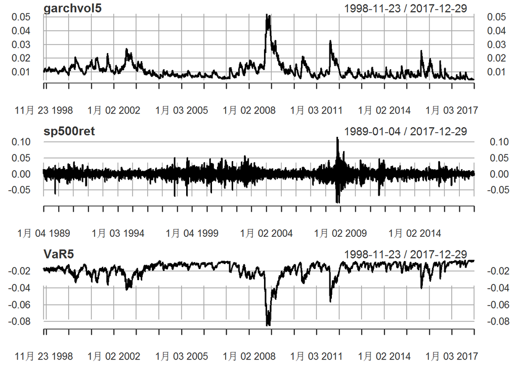

```r
garchvol5 <- xts(preds5$Sigma, order.by = as.Date(rownames(preds5)))
VaR5 <- xts(garchroll5@forecast$VaR$`alpha(5%)`, order.by = as.Date(rownames(preds5)))
par(mfrow = c(3 , 1))
plot(garchvol5)
plot(sp500ret)
plot(VaR5)
```

## 3.c

**Question**

A VaR exceedance occurs when the actual return is less than the predicted value-at-risk: Rt < VaRt. Plot the scattered points of actual returns, the predicted $VaRt(\alpha)$, and highlight the VaR exceedance points by different color.

**Answer**

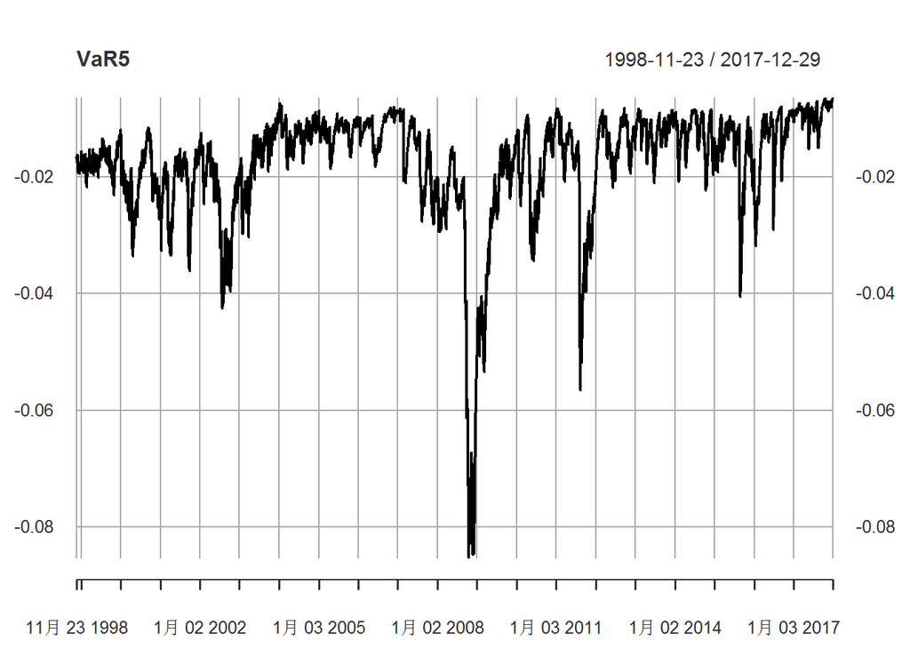

```r
VaR5 <- xts(garchroll5@forecast$VaR$`alpha(5%)`, order.by = as.Date(rownames(preds5)))
plot(VaR5)
```

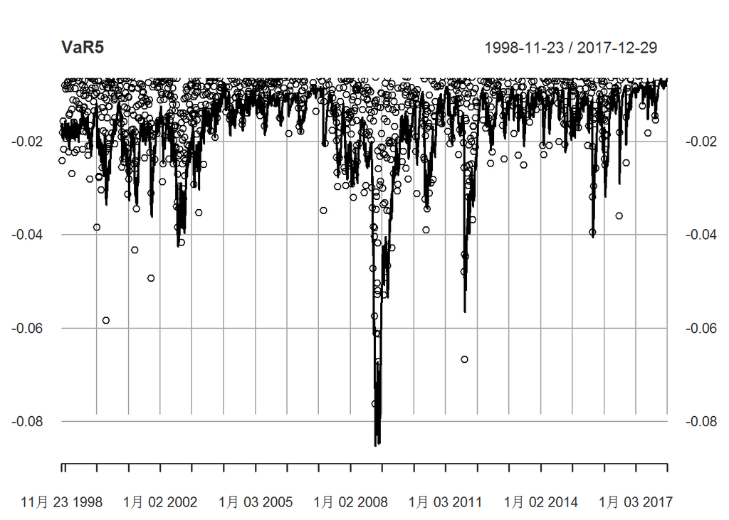

```r
# par(new=TRUE)
points(sp500ret["1998-11-23/"])
```

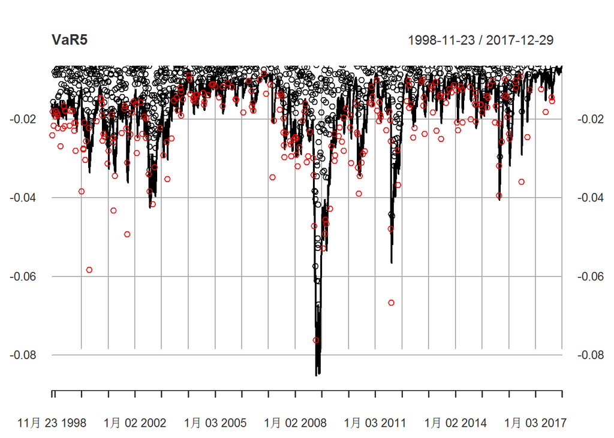

```r
points(sp500ret["1998-11-23/"][sp500ret["1998-11-23/"] < VaR5] , col = "red")
```

## 3.d

**Question**

The frequency of VaR exceedances is called the VaR coverage. A valid prediction model has a coverage that is close to the probability level $\alpha$ used. If coverage > $\alpha$ : too many exceedances: the predicted quantile should be more negative. Risk of losing money has been underestimated.If coverage < $\alpha$ : too few exceedances, the predicted quantile was too negative. Risk of losing money has been overestimated. Compute the VaR coverage of the AR(1)-GJR-GARCH with skew-t distribution, AR(1)-GJR-GARCH with t distribution, AR(1)GARCH with t distribution, and AR(1)-GJR-GARCH with skew-t distribution with rolling estimation implemented every 1000 observations instead of 100. You can create a table to display your results.

**Answer**

We can find that the AR(1)-GJR-GARCH with skew-t distribution has the best coverage result that is 0.05159143 from the table printed below, which is consistent with the result in part(a). By the way, the models has been estimated in part(a), so here we use the models estimated in part(a) to calculate the coverage directly.

```r
# first model
VaR1 <- xts(garchroll1@forecast$VaR$`alpha(5%)`, order.by = as.Date(rownames(preds1)))
coverage1 <- (length(VaR1[sp500ret["1998-11-23/"] < VaR1]) / length(sp500ret["1998-11-23/"]))

# second model
garchvol2 <- xts(preds2$Sigma, order.by = as.Date(rownames(preds2)))
VaR2 <- xts(garchroll2@forecast$VaR$`alpha(5%)`, order.by = as.Date(rownames(preds2)))
coverage2 <- (length(VaR2[sp500ret["1998-11-23/"] < VaR2]) / length(sp500ret["1998-11-23/"]))

# third model
garchvol3 <- xts(preds3$Sigma, order.by = as.Date(rownames(preds3)))
VaR3 <- xts(garchroll3@forecast$VaR$`alpha(5%)`, order.by = as.Date(rownames(preds3)))
coverage3 <- (length(VaR3[sp500ret["1998-11-23/"] < VaR3]) / length(sp500ret["1998-11-23/"]))

# forth model
garchvol4 <- xts(preds4$Sigma, order.by = as.Date(rownames(preds4)))
VaR4 <- xts(garchroll4@forecast$VaR$`alpha(5%)`, order.by = as.Date(rownames(preds4)))
coverage4 <- (length(VaR4[sp500ret["1998-11-23/"] < VaR4]) / length(sp500ret["1998-11-23/"]))

coverage1
```

```
## [1] 0.05159143
```

```r
coverage2
```

```
## [1] 0.05783233
```

```r
coverage3
```

```
## [1] 0.06074475
```

```r
coverage4
```

```
## [1] 0.05512794
```

```r
coverage.df <- data.frame(Model1 = coverage1 , Model2=coverage2 , Model3 = coverage3 , Model4 = coverage4)
coverage.df
```

```
##       Model1     Model2     Model3     Model4
## 1 0.05159143 0.05783233 0.06074475 0.05512794
```